# Yash Manish Raichura PS3

```python
import pandas as pd
import numpy as np
import sklearn
from scipy.stats.stats import pearsonr
import scipy
import seaborn as sb
from sklearn.model_selection import train_test_split
from sklearn.linear_model import LogisticRegression
from sklearn.svm import SVC
from sklearn.metrics import f1_score
from sklearn.neighbors import KNeighborsClassifier
from sklearn import preprocessing
from sklearn.preprocessing import normalize
from statistics import mean

%matplotlib inline
```

# Introduction

This problem set should not be hard per se but it may be very slow in terms of computing. You are mostlyasked just to use existing packages to analyze a big survey dataset. The problem set has two parts: first you try to get as good a prediction as you can using k-NN, logistic regression and SVM methods, and thereafter you analyze how much does knowledge of country of the respondent improve our prediction. The problem set has 4 goals: a) explore classification methods we have learned in a novel context (a large survey) b) learn more about cross validation c) learn a little bit about the global opinion (but we don't do the latter that rigorously).

# World Values Survey

In this database we use World Values Survey data. The data is free to be downloaded from the webpage, just you have to sign up but I expect to download the version on canvas. It is a survey, conducted every few years in a number of countries. Here we use wave 6 data, mostly from 2013-2014. Note that not all countries are participating in each wave. The questions revolve around different opinion topics, including trust, work, religion, family, gender equality, and nationalism. In this problem set we focus on what the respondents think about abortion: "Please tell if abortion can always be justified, never be justified, or something in between". The responses range between 1 - never justifiable, and 10 - always justifiable. Besides of the numeric range 1..10, a number of cases have negative codes (this applies to many variables). These are various types of missing information (-5: missing, -4: not asked, -3: not applicable, -2: no answer, -1: don't know). We treat all these as just missing below. The version we use here is a little bit simplified, I have removed a large number of variables that are constructed from the other variables and hence highly collinear with the rest of the data. I strongly recommend you to browse the documentation before you start, there are two large-ish documentation files provided.

# 1 Explore and prepare the data (20pt)

As the first step, explore the data.

### 1. (2pt) Load the data. How many responses and variables do we have?

```python
wvs = pd.read_csv('wvs.csv', sep = '\t')
```

```python
wvs.head()
```

|  | V2 | V4 | V5 | V6 | V7 | V8 | V9 | V10 | V11 | V12 | ... | MN_228S8 | MN_229A | MN_230A | MN_233A | MN_237B1 | MN_249A1 | MN_249A3 | I_RELIGBEL | I_NORM1 | I_VOICE1 |
| --- | --- | --- | --- | --- | --- | --- | --- | --- | --- | --- | --- | --- | --- | --- | --- | --- | --- | --- | --- | --- | --- |
| 0 | 12 | 1 | 1 | 1 | -2 | 1 | 1 | 2 | 1 | 1 | ... | 3 | -3 | -3 | -3 | -3 | 1 | 1 | 0.0 | 1.0 | 0.00 |
| 1 | 12 | 1 | 2 | 3 | 4 | 2 | 2 | 2 | 2 | 2 | ... | 3 | -3 | -3 | -3 | -3 | 2 | -1 | 0.0 | 1.0 | 0.66 |
| 2 | 12 | 1 | 3 | 2 | 4 | 2 | 1 | 2 | 2 | 2 | ... | 4 | 1 | 1 | 2 | -3 | 1 | 1 | 0.0 | 1.0 | 0.33 |
| 3 | 12 | 1 | 1 | 3 | 4 | 3 | 1 | 2 | 1 | 2 | ... | 2 | 2 | 1 | 2 | -3 | 1 | 2 | 0.0 | 1.0 | 0.00 |
| 4 | 12 | 1 | 1 | 1 | 2 | 1 | 1 | 1 | 3 | 2 | ... | 2 | 2 | 1 | 2 | -3 | 1 | 2 | 0.0 | 1.0 | 0.66 |

5 rows × 328 columns

```python
wvs.shape
```

```
(90350, 328)
```

```python
wvs.info()
```

```
<class 'pandas.core.frame.DataFrame'>
RangeIndex: 90350 entries, 0 to 90349
Columns: 328 entries, V2 to I_VOICE1
dtypes: float64(6), int64(322)
memory usage: 226.1 MB
```

```python
wvs.describe()
```

|  | V2 | V4 | V5 | V6 | V7 | V8 | V9 | V10 | V11 | V12 | ... | MN_228S8 | MN_229A | MN_230A | MN_233A | MN_237B1 | MN_249A1 | MN_249A3 | I_RELIGBEL | I_NORM1 | I_VOICE1 |
| --- | --- | --- | --- | --- | --- | --- | --- | --- | --- | --- | --- | --- | --- | --- | --- | --- | --- | --- | --- | --- | --- |
| count | 90350.00000 | 90350.000000 | 90350.000000 | 90350.000000 | 90350.000000 | 90350.000000 | 90350.000000 | 90350.000000 | 90350.000000 | 90350.000000 | ... | 90350.000000 | 90350.000000 | 90350.000000 | 90350.000000 | 90350.000000 | 90350.000000 | 90350.000000 | 85714.000000 | 88639.000000 | 85905.000000 |
| mean | 467.39803 | 1.094422 | 1.661738 | 1.852872 | 2.544638 | 1.470293 | 1.834566 | 1.831334 | 2.077731 | 1.476989 | ... | -3.351942 | -3.444538 | -3.576193 | -3.512053 | -3.818771 | -3.511942 | -3.519712 | 0.318618 | 0.463351 | 0.333420 |
| std | 248.45177 | 0.405737 | 0.777382 | 0.914146 | 1.113079 | 0.948833 | 1.115576 | 0.796195 | 0.880672 | 0.505486 | ... | 1.958910 | 1.664554 | 1.415837 | 1.678706 | 0.715046 | 1.514230 | 1.501295 | 0.465943 | 0.498658 | 0.315851 |
| min | 12.00000 | -5.000000 | -5.000000 | -5.000000 | -5.000000 | -5.000000 | -5.000000 | -5.000000 | -5.000000 | -5.000000 | ... | -4.000000 | -4.000000 | -4.000000 | -4.000000 | -4.000000 | -5.000000 | -5.000000 | 0.000000 | 0.000000 | 0.000000 |
| 25% | 276.00000 | 1.000000 | 1.000000 | 1.000000 | 2.000000 | 1.000000 | 1.000000 | 1.000000 | 1.000000 | 1.000000 | ... | -4.000000 | -4.000000 | -4.000000 | -4.000000 | -4.000000 | -4.000000 | -4.000000 | 0.000000 | 0.000000 | 0.000000 |
| 50% | 434.00000 | 1.000000 | 2.000000 | 2.000000 | 3.000000 | 1.000000 | 1.000000 | 2.000000 | 2.000000 | 1.000000 | ... | -4.000000 | -4.000000 | -4.000000 | -4.000000 | -4.000000 | -4.000000 | -4.000000 | 0.000000 | 0.000000 | 0.330000 |
| 75% | 702.00000 | 1.000000 | 2.000000 | 2.000000 | 3.000000 | 2.000000 | 3.000000 | 2.000000 | 3.000000 | 2.000000 | ... | -4.000000 | -4.000000 | -4.000000 | -4.000000 | -4.000000 | -4.000000 | -4.000000 | 1.000000 | 1.000000 | 0.660000 |
| max | 887.00000 | 4.000000 | 4.000000 | 4.000000 | 4.000000 | 4.000000 | 4.000000 | 4.000000 | 4.000000 | 2.000000 | ... | 4.000000 | 2.000000 | 2.000000 | 5.000000 | 1.000000 | 2.000000 | 2.000000 | 1.000000 | 1.000000 | 1.000000 |

8 rows × 328 columns

We have 328 variables and 90350 observations

### 2. (3pt) Create a summary table over all responses for V204 : is abortion justifiable. How many nonmissing responses (i.e. positive answers) do you find? Describe the the opinion about the abortion among the global pool of respondents.

```python
wvs_V204 = pd.DataFrame(wvs.V204.value_counts(dropna = False))
wvs_V204.rename(columns = {'V204' : 'Count'}, inplace = True)
wvs_V204.index.name = 'Response'
wvs_V204
```

| Response | Count |
| --- | --- |
| 1 | 40227 |
| 5 | 9580 |
| 2 | 7896 |
| 3 | 6294 |
| 4 | 4497 |
| 6 | 4395 |
| 10 | 4067 |
| 7 | 3493 |
| 8 | 3397 |
| -1 | 2017 |
| 9 | 1896 |
| -4 | 1523 |
| -2 | 1045 |
| -5 | 23 |

```python
wvs.V204.isnull().sum()
```

```
0
```

```python
wvs_V204.Count.sum()
```

```
90350
```

```python
wvs_V204['Percentage'] = ((wvs_V204.Count/wvs_V204.Count.sum())*100).round(2)
wvs_V204
```

| Response | Count | Percentage |
| --- | --- | --- |
| 1 | 40227 | 44.52 |
| 5 | 9580 | 10.60 |
| 2 | 7896 | 8.74 |
| 3 | 6294 | 6.97 |
| 4 | 4497 | 4.98 |
| 6 | 4395 | 4.86 |
| 10 | 4067 | 4.50 |
| 7 | 3493 | 3.87 |
| 8 | 3397 | 3.76 |
| -1 | 2017 | 2.23 |
| 9 | 1896 | 2.10 |
| -4 | 1523 | 1.69 |
| -2 | 1045 | 1.16 |
| -5 | 23 | 0.03 |

Above, we see that a total of 90350 responses were recorded. Out of these approximately 45% of the participants feel that abortion is never justifiable and 4.5% people feel that abortion is always justifiable

```python
wvs_V204.reset_index(inplace = True)
wvs_V204
```

|  | Response | Count | Percentage |
| --- | --- | --- | --- |
| 0 | 1 | 40227 | 44.52 |
| 1 | 5 | 9580 | 10.60 |
| 2 | 2 | 7896 | 8.74 |
| 3 | 3 | 6294 | 6.97 |
| 4 | 4 | 4497 | 4.98 |
| 5 | 6 | 4395 | 4.86 |
| 6 | 10 | 4067 | 4.50 |
| 7 | 7 | 3493 | 3.87 |
| 8 | 8 | 3397 | 3.76 |
| 9 | -1 | 2017 | 2.23 |
| 10 | 9 | 1896 | 2.10 |
| 11 | -4 | 1523 | 1.69 |
| 12 | -2 | 1045 | 1.16 |
| 13 | -5 | 23 | 0.03 |

```python
wvs_V204.loc[wvs_V204.Response >0, 'Count'].sum()
```

```
85742
```

There are a total of 85742 non-missing responses

### 3. (4pt) Now remove missings. We do it in two ways:

### (a) remove everything that are not positive integers for V204 and V2 (country).

### (b) for all other variables, remove the missings in the sense of missing value on computer. You may leave negative answers in the data, otherwise I am afraid your sample size collapses. What is the final number of observations?

```python
# Removing all the negative values from V204 and V2
wvs= wvs[(wvs.V204>0) &(wvs.V2>0)]
```

```python
#Checking for NA values in columns V2 and V204
print('NA Values in column V2 - ' + str(wvs.V2.isna().sum()))
print('NA Values in column V204 - ' +  str(wvs.V204.isna().sum()))

# Removing NA values for all other columns
wvs.dropna(axis = 1, inplace = True)
```

```
NA Values in column V2 - 0
NA Values in column V204 - 0
```

```python
wvs.shape
```

```
(85742, 324)
```

The total number of observations are 85742

```python
wvs['Abortion'] = np.where(wvs['V204']>3, 1, 0)
```

```python
wvs.Abortion.value_counts()
```

```
0    54417
1    31325
Name: Abortion, dtype: int64
```

```python
wvs.head()
```

|  | V2 | V4 | V5 | V6 | V7 | V8 | V9 | V10 | V11 | V12 | ... | MN_228S6 | MN_228S7 | MN_228S8 | MN_229A | MN_230A | MN_233A | MN_237B1 | MN_249A1 | MN_249A3 | Abortion |
| --- | --- | --- | --- | --- | --- | --- | --- | --- | --- | --- | --- | --- | --- | --- | --- | --- | --- | --- | --- | --- | --- |
| 0 | 12 | 1 | 1 | 1 | -2 | 1 | 1 | 2 | 1 | 1 | ... | 3 | 2 | 3 | -3 | -3 | -3 | -3 | 1 | 1 | 0 |
| 1 | 12 | 1 | 2 | 3 | 4 | 2 | 2 | 2 | 2 | 2 | ... | 2 | 4 | 3 | -3 | -3 | -3 | -3 | 2 | -1 | 0 |
| 2 | 12 | 1 | 3 | 2 | 4 | 2 | 1 | 2 | 2 | 2 | ... | 2 | 4 | 4 | 1 | 1 | 2 | -3 | 1 | 1 | 0 |
| 3 | 12 | 1 | 1 | 3 | 4 | 3 | 1 | 2 | 1 | 2 | ... | 3 | 3 | 2 | 2 | 1 | 2 | -3 | 1 | 2 | 0 |
| 4 | 12 | 1 | 1 | 1 | 2 | 1 | 1 | 1 | 3 | 2 | ... | 1 | 3 | 2 | 2 | 1 | 2 | -3 | 1 | 2 | 0 |

5 rows × 325 columns

### 5. (5pt) Compute (pearson) correlation table between abortion and all other variables in the data. There are many of these! Present these variables in descending order according to the absolute value of the correlation

```python
# I have a doubt here, isn't correlation supposed to be calculated between continuous, normally distributed variables? Thank you
a = wvs[['Abortion', 'V2']]
```

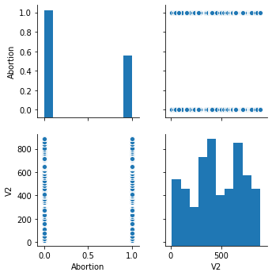

```python
sb.pairplot(a)
```

```python
pearson_coefficient= {'correlation': wvs[wvs.columns[1:]].corr()['Abortion']}
```

```python
pearson_coefficient
```

```
{'correlation': V4          0.050740
 V5         -0.027232
 V6         -0.069952
 V7          0.003776
 V8          0.073926
               ...
 MN_233A    -0.089027
 MN_237B1   -0.063596
 MN_249A1   -0.095566
 MN_249A3   -0.094517
 Abortion    1.000000
 Name: Abortion, Length: 324, dtype: float64}
```

```python
pearson = pd.DataFrame(pearson_coefficient)
pearson
```

|  | correlation |
| --- | --- |
| V4 | 0.050740 |
| V5 | -0.027232 |
| V6 | -0.069952 |
| V7 | 0.003776 |
| V8 | 0.073926 |
| ... | ... |
| MN_233A | -0.089027 |
| MN_237B1 | -0.063596 |
| MN_249A1 | -0.095566 |
| MN_249A3 | -0.094517 |
| Abortion | 1.000000 |

324 rows × 1 columns

```python
pearson.sort_values(by = 'correlation' ,ascending = False, inplace = True)
```

```python
pearson
```

|  | correlation |
| --- | --- |
| Abortion | 1.000000 |
| V204 | 0.881411 |
| V205 | 0.545344 |
| V203 | 0.468681 |
| V206 | 0.437933 |
| ... | ... |
| V138 | -0.140154 |
| V255 | -0.152302 |
| V223 | -0.153491 |
| V252 | -0.193340 |
| V152 | -0.273598 |

324 rows × 1 columns

The variables which have a strong correlation with Abortion are V204, which is the column of which abortion column was calculated. V205 has a correlation of 0.55 with Abortion. It is the column for Divorce. It suggests that a lot of respondents who voted never justifiable for abortion also voted never justifiable for divorce and vice versa. Other columns which show a correlation around 0.5 are V203 ane V206 which are columns for 'Homosexuality' and 'Sex before Marriage'. This can suggest some behavioral patterns within the respondents suggesting their prenotions.

### 6. (4pt) convert country code V2 into dummies. First rename V2 to country. Afterwards, remove country variable from the data. How many rows/columns do you have now? How many country dummies does the data contain?

```python
wvs.rename(columns={"V2": "country"}, inplace = True)
```

```python
data2 = pd.get_dummies(wvs, columns = ['country'])
```

```python
data2.shape
```

```
(85742, 383)
```

```python
data2.head()
```

|  | V4 | V5 | V6 | V7 | V8 | V9 | V10 | V11 | V12 | V13 | ... | country_752 | country_764 | country_780 | country_788 | country_792 | country_804 | country_840 | country_858 | country_860 | country_887 |
| --- | --- | --- | --- | --- | --- | --- | --- | --- | --- | --- | --- | --- | --- | --- | --- | --- | --- | --- | --- | --- | --- |
| 0 | 1 | 1 | 1 | -2 | 1 | 1 | 2 | 1 | 1 | 1 | ... | 0 | 0 | 0 | 0 | 0 | 0 | 0 | 0 | 0 | 0 |
| 1 | 1 | 2 | 3 | 4 | 2 | 2 | 2 | 2 | 2 | 1 | ... | 0 | 0 | 0 | 0 | 0 | 0 | 0 | 0 | 0 | 0 |
| 2 | 1 | 3 | 2 | 4 | 2 | 1 | 2 | 2 | 2 | 2 | ... | 0 | 0 | 0 | 0 | 0 | 0 | 0 | 0 | 0 | 0 |
| 3 | 1 | 1 | 3 | 4 | 3 | 1 | 2 | 1 | 2 | 2 | ... | 0 | 0 | 0 | 0 | 0 | 0 | 0 | 0 | 0 | 0 |
| 4 | 1 | 1 | 1 | 2 | 1 | 1 | 1 | 3 | 2 | 1 | ... | 0 | 0 | 0 | 0 | 0 | 0 | 0 | 0 | 0 | 0 |

5 rows × 383 columns

```python
wvs.shape
```

```
(85742, 325)
```

```python
data2.drop(columns = ['V204'], inplace = True)
```

```python
data2.shape
```

```
(85742, 382)
```

Since there were 59 different countries in the wvs dataframe, 59 dummy variables were created for each country and hence the total number of variables went from 325 to 383. The number of observations are the same i.e. 85742

# 2 Implement Cross-Validation (40pt)

```python
def cv(k,model,X,Y,df,normalization):
    f1=[]
    accuracy=[]
    shuffled_df = df.sample(frac=1).reset_index(drop=True)


    if normalization == 'yes':
        normal_scale = preprocessing.MinMaxScaler()
        shuffled_df = normal_scale.fit_transform(shuffled_df)
        shuffled_df = pd.DataFrame(shuffled_df, columns = df.columns)
    k_folds = [shuffled_df[i::k] for i in range(k)]

    for i in range(k):

        test=k_folds[i]
        train = shuffled_df[~shuffled_df.index.isin(test.index)]
        train_x = train[X]
        train_y = train[Y]
        test_x = test[X]
        test_y = test[Y]
        model.fit(train_x,train_y)

        predict= model.predict(test_x)
        f1.append(f1_score(test_y, predict))
        accuracy.append(model.score(test_x, test_y))

    print('accuracy')
    print(mean(accuracy))

    print('f1 score')
    print(mean(f1))
```

# 3 Find the best model (40)

#### In this section your task is to find which model: k-NN, logistic regression, or SVM works best. You will evaluate the model performance using 5-fold cross-validation with accuracy and F-score as the metric. And unlike in all your future work, here you will use your own CV impementation! k-NN and SVM are sensitive to the distance metric, so you may also try to normalized versus nonnormalized features. Check out sklearn.preprocessing.normalize. Logistic regression is agnostic with respect to the metric, but may benefit from more similar variable values for numerical reasons. Some of the methods (k-NN, SVM) are slow to compute, so you may start with a subset of data (say, 5000 random lines only). If everything turns out fine, you increase the data size as far as your computer can go.

### 3.1 k-NN (13pt)

#### First, use k-NN and experiment with a few different k-s.

#### 1. (2pt) Separate your training data into X (features), and y (target). Target will be the abortion variable, X are all the other features.

#### 2. (2pt) pick a k and set up the k-NN model. Use your freshly-minted CV routine to cross-validate accuracy and F-score of your k-NN model.

#### 3. (5pt) Try a few different k-NN models (pick different k, choose to normalize/not-to-normalize your features).

#### 4. (4pt) Present the results from your best k-NN model. Note: as you are using two metrics here, you may end up with different models performing better according to different measures

```python
X=data2.columns
#splitting the data
x_train, x_test, y_train, y_test = train_test_split(data2, data2.Abortion, test_size=0.2)
```

```python
#using subset of the data
wvs_df = data2.iloc[0:1000]
```

```python
# KNN with k = 5
knn = KNeighborsClassifier(n_neighbors = 5)
```

```python
cv(3, knn, X, 'Abortion',wvs_df,'')
```

```
accuracy
0.7930325535115954
f1 score
0.40097803431136764
```

```python
# KNN with K = 10

knn = KNeighborsClassifier(n_neighbors = 10)
cv(10, knn, X, 'Abortion',wvs_df,'')
```

```
accuracy
0.777
f1 score
0.23926428101380665
```

```python
#With and without Normalization for k = 3

knn = KNeighborsClassifier(n_neighbors = 3)
cv(3, knn, X, 'Abortion',wvs_df,'yes')
```

```
accuracy
0.8189866513219807
f1 score
0.5369106280193238
```

```python
#Without Normalization

knn = KNeighborsClassifier(n_neighbors = 3)
cv(3, knn, X, 'Abortion',wvs_df,'')
```

```
accuracy
0.7920015824207441
f1 score
0.4779183128475271
```

### 3.2 Logistic Regression (9pt)

#### 1. Now repeat the process above with logistic regression. As we have a myriad of features anyway, we are not going to do any feature engineering. Just a plain logistic regression.

```python
cv(5, LogisticRegression(), X, 'Abortion', wvs_df,'')
```

```
accuracy
0.913
f1 score
0.8190238519650285
```

### 3.3 SVM (15pt)

#### Now repeat the process with support vector machines while choosing between a few different kernels and kernel options, such as degree for polynomial kernels. Hint: I have mixed experience with sklearn version of SVM. I recommend to limit the number of iterations, initially maybe to just 1000, in order to ensure your model actually terminates.

#### 1. (14pt) pick a kernel and repeat the process above. Note that some kernels are slower than others, so be careful.

#### 2. (2pt) If your models worked like mine, you may have noticed that while accuracy seems all right, precision and recall are rather low. Explain what does such a phenomenon mean.

```python
svm_linear = SVC(kernel = 'linear')
```

```python
cv(3, svm_linear, X, 'Abortion',wvs_df,'')
```

```
accuracy
0.893989798181415
f1 score
0.7897493453049009
```

```python
svm_kernel_2 = SVC(kernel = 'poly',gamma=2)
```

```python
cv(10, svm_kernel_2, X, 'Abortion',wvs_df,'')
```

```
accuracy
0.871
f1 score
0.7199054972664679
```

```python
#changing the degree of ploynomial
svm_kernel_3 = SVC(kernel = 'poly',degree=3,gamma='scale')
cv(10, svm_kernel_3, X, 'Abortion',wvs_df,'')
```

```
accuracy
0.85
f1 score
0.6489075562043946
```

```python
svm_kernel_4 =SVC(kernel='rbf', gamma='scale')
cv(10, svm_kernel_4, X, 'Abortion',wvs_df,'')
```

```
accuracy
0.84
f1 score
0.583420284613409
```

f1 score = 2 (precision * recall)/ (precision + recall) precision = true Positive / total predicted positive recall = true positive/ total actual positives

This suggests that even if the accuracy is high, the number of true positives are not a lot and hence there is a dip in the f1 score.

### 3.4 Compare the models (3pt)

#### 1. (2pt) Finally, compare the models. Which ones performed the best in terms of accuracy? Which ones in terms of F-score? Did you encounter other kind of issues with certain models? Which models were fast and which ones slow?

#### 2. (1pt) If you have to repeat the exercise with a single model (and you have, see below), which one will you pick?

Logistic Regression with 5 fold cross validation outperforms all of them with accuracy of 0.913 and an f1 score of 0.819. In terms of execution, logistic regression was the fastest and SVM was the slowest.

Logistic Regression clearly gave the best accuracy and f1 score and was the quickest in execution too and hence that model should seems like a good option.

# 4 How large a role does country play? (20pt)

### Here we switch from machine learning to social sciences. Public opinion diers from country to country, but also inside the countries. Does the fact that we include country code in data help us to substantially improve the predictions? You pick the best ML method from above. You estimate two sets of models: one with country information included, and one where it is removed. Is the former noticeably better than the latter?

### 1. (10pt) Pick your best ML method based you designed above. Cross-validate the accuracy of abortion variable using all the features, including country dummies and report the accuracy. Essentially you repeat here what you did above, so you can also just copy the result from above.

### 2. (15pt) Now remove all the country dummies, but keep the other variables intact. And repeat.

### 3. (5pt) Comment what you found. Does country information help to noticeably improve the prediction?

```python
cv(5, LogisticRegression(), X, 'Abortion', wvs_df,'')
```

```
accuracy
0.91
f1 score
0.814901165986847
```

Accuracy is 0.91 and f1 score is 0.814 approximately.

```python
wvs_df_1 = wvs_df.copy()
wvs_df_1 = wvs_df_1.loc[:, ~wvs_df_1.columns.str.startswith('country')]
wvs_df_1.head()
```

|  | V4 | V5 | V6 | V7 | V8 | V9 | V10 | V11 | V12 | V13 | ... | MN_228S6 | MN_228S7 | MN_228S8 | MN_229A | MN_230A | MN_233A | MN_237B1 | MN_249A1 | MN_249A3 | Abortion |
| --- | --- | --- | --- | --- | --- | --- | --- | --- | --- | --- | --- | --- | --- | --- | --- | --- | --- | --- | --- | --- | --- |
| 0 | 1 | 1 | 1 | -2 | 1 | 1 | 2 | 1 | 1 | 1 | ... | 3 | 2 | 3 | -3 | -3 | -3 | -3 | 1 | 1 | 0 |
| 1 | 1 | 2 | 3 | 4 | 2 | 2 | 2 | 2 | 2 | 1 | ... | 2 | 4 | 3 | -3 | -3 | -3 | -3 | 2 | -1 | 0 |
| 2 | 1 | 3 | 2 | 4 | 2 | 1 | 2 | 2 | 2 | 2 | ... | 2 | 4 | 4 | 1 | 1 | 2 | -3 | 1 | 1 | 0 |
| 3 | 1 | 1 | 3 | 4 | 3 | 1 | 2 | 1 | 2 | 2 | ... | 3 | 3 | 2 | 2 | 1 | 2 | -3 | 1 | 2 | 0 |
| 4 | 1 | 1 | 1 | 2 | 1 | 1 | 1 | 3 | 2 | 1 | ... | 1 | 3 | 2 | 2 | 1 | 2 | -3 | 1 | 2 | 0 |

5 rows × 323 columns

```python
X1= wvs_df_1.columns
cv(5, LogisticRegression(), X1, 'Abortion', wvs_df_1,'')
```

```
accuracy
0.923
f1 score
0.8415103212448904
```

The accuracy and the f score remains almost the same and removing the country dummy variable had no significant impact.